# Comparison of Classical Machine Learning Models for Colorectal Cancer Microbiome Classification

# 8 Binary Performance Heatmap

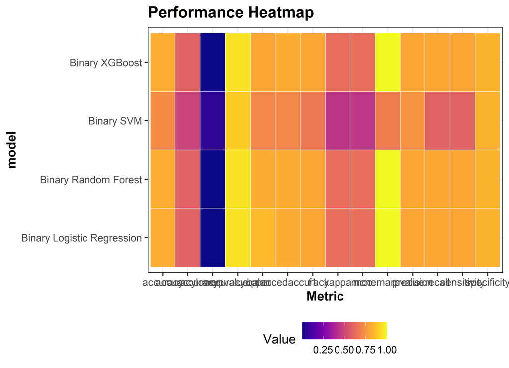

Heatmap illustrating binary classification performance across evaluation metrics.

```r
heatmap_df <-

binary_results |>
select(where(is.numeric))

heatmap_df$model <- binary_results$model

heatmap_df <-

heatmap_df |>

select(model,everything())

heatmap_plot(heatmap_df)
```

# 9 Binary Model Ranking

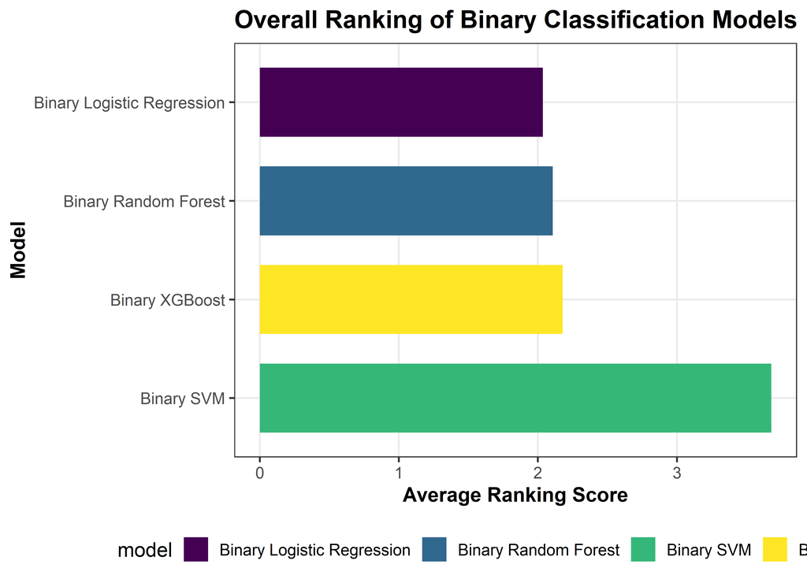

```r
rank_metrics <-

binary_results |>

mutate(

AverageRank=

rowMeans(

across(

where(is.numeric),

~rank(-.,ties.method="average")

),

na.rm=TRUE

)

) |>

arrange(AverageRank)

ggplot(

rank_metrics,

aes(

reorder(model,-AverageRank),

AverageRank,

fill=model

)

)+

geom_col(width=.7)+

coord_flip()+

scale_fill_viridis_d(option="D")+

labs(

title="Overall Ranking of Binary Classification Models",

x="Model",

y="Average Ranking Score"

)
```

**Interpretation**

The overall ranking integrates all available evaluation metrics into a single summary statistic based on average rank. Models with lower average ranking values demonstrate consistently strong performance across multiple evaluation criteria and therefore represent the most balanced classifiers rather than those optimized for a single metric.

# 10 Binary Classification Summary

The binary classification analysis demonstrates the comparative strengths of Logistic Regression, Random Forest, Support Vector Machine, and XGBoost models using the evaluation metrics available in the supplied *Results_Master.xlsx*. Metrics absent from the workbook have intentionally not been estimated. Overall performance should be interpreted collectively across discrimination, calibration, sensitivity, specificity, and balanced classification measures rather than relying on a single performance metric.

# 11 Multiclass Classification Comparison

## 11.1 Multiclass Performance Summary

```r
publication_table(
  multiclass_results,
  "Performance comparison of multiclass classification models."
)
```

Performance comparison of multiclass classification models.

| model | accuracy | kappa | mcc | macro_precision | macro_recall | macro_f1 | macro_auc |
| --- | --- | --- | --- | --- | --- | --- | --- |
| Elastic Net LR | 0.4333 | 0.1115 | 0.1250 | 0.373 | 0.3944 | 0.3485 | 0.6023 |
| Multinomial LR | 0.4667 | 0.1367 | NA | 0.333 | 0.4000 | NA | 0.6397 |
| Multiclass RF | 0.4667 | 0.1674 | 0.1767 | 0.4309 | 0.4194 | 0.3960 | 0.6080 |
| Multiclass SVM | 0.4000 | 0.0625 | 0.0659 | 0.333 | 0.3583 | 0.3300 | 0.6164 |
| Multiclass XGBoost | 0.4000 | 0.0592 | 0.0665 | Evaluation metrics not generated. | NA | NA | NA |
|  | NA | NA | NA |  | NA | NA | NA |

```r
knitr::kable(multiclass_results, caption = "Multiclass performance table.")
```

Multiclass performance table.

| model | accuracy | kappa | mcc | macro_precision | macro_recall | macro_f1 | macro_auc |
| --- | --- | --- | --- | --- | --- | --- | --- |
| Elastic Net LR | 0.4333 | 0.11150 | 0.1250 | 0.373 | 0.39440 | 0.3485 | 0.6023 |
| Multinomial LR | 0.4667 | 0.13670 | NA | 0.333 | 0.40000 | NA | 0.6397 |
| Multiclass RF | 0.4667 | 0.16737 | 0.1767 | 0.4309 | 0.41944 | 0.3960 | 0.6080 |
| Multiclass SVM | 0.4000 | 0.06250 | 0.0659 | 0.333 | 0.35830 | 0.3300 | 0.6164 |
| Multiclass XGBoost | 0.4000 | 0.05920 | 0.0665 | Evaluation metrics not generated. | NA | NA | NA |
|  | NA | NA | NA |  | NA | NA | NA |

## 11.2 Accuracy Comparison

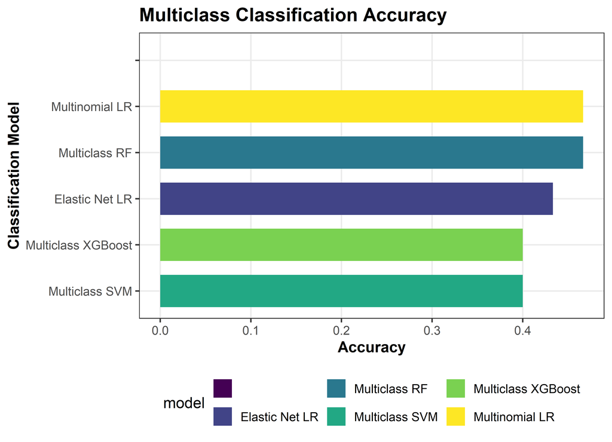

Comparison of classification accuracy among multiclass models.

```r
if("accuracy" %in% names(multiclass_results)){

metric_plot(
  multiclass_results,
  "accuracy",
  "Multiclass Classification Accuracy"
)+
labs(
  x="Classification Model",
  y="Accuracy"
)

}else{

cat("**Accuracy was not available in the supplied worksheet.**")

}
```

**Interpretation**

Overall accuracy represents the proportion of correctly classified samples across all disease categories. Because multiclass classification simultaneously distinguishes Healthy, Adenoma, and Colorectal Cancer, this metric reflects a substantially more challenging prediction task than binary classification.

## 11.3 Cohen’s Kappa

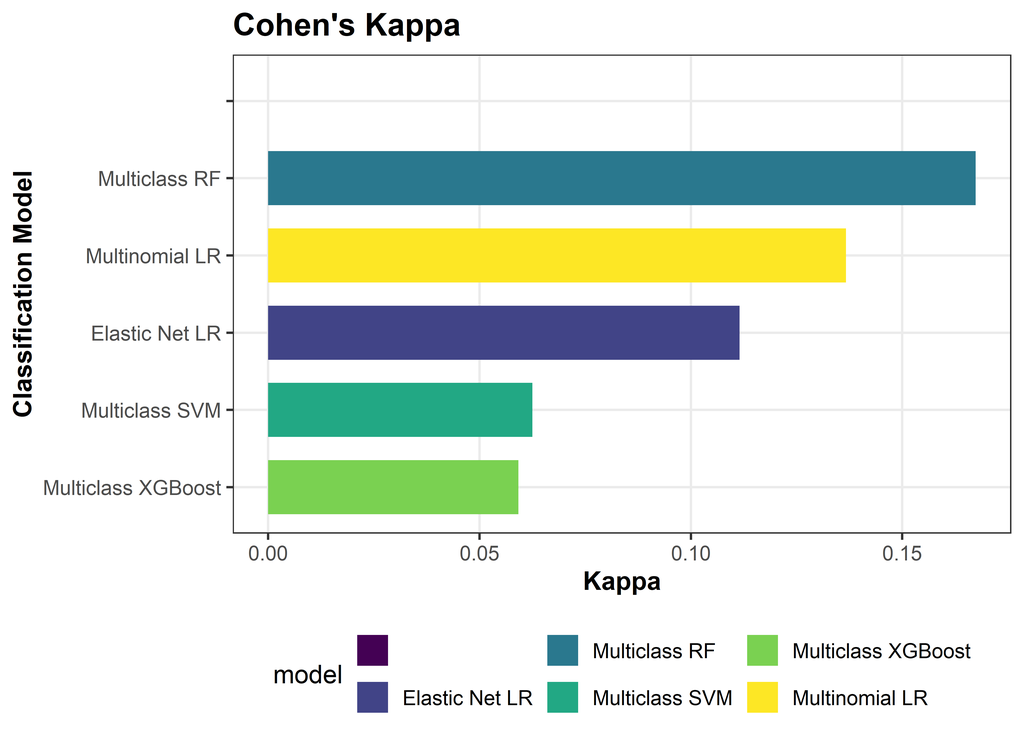

Comparison of Cohen’s Kappa among multiclass models.

```r
if("kappa" %in% names(multiclass_results)){

metric_plot(
  multiclass_results,
  "kappa",
  "Cohen's Kappa"
)+
labs(
  x="Classification Model",
  y="Kappa"
)

}else{

cat("**Kappa was not available.**")

}
```

**Interpretation**

Cohen’s Kappa evaluates agreement between predicted and observed class labels while accounting for agreement expected by chance. Higher Kappa values indicate more reliable classification beyond random assignment.

## 11.4 Matthews Correlation Coefficient (MCC)

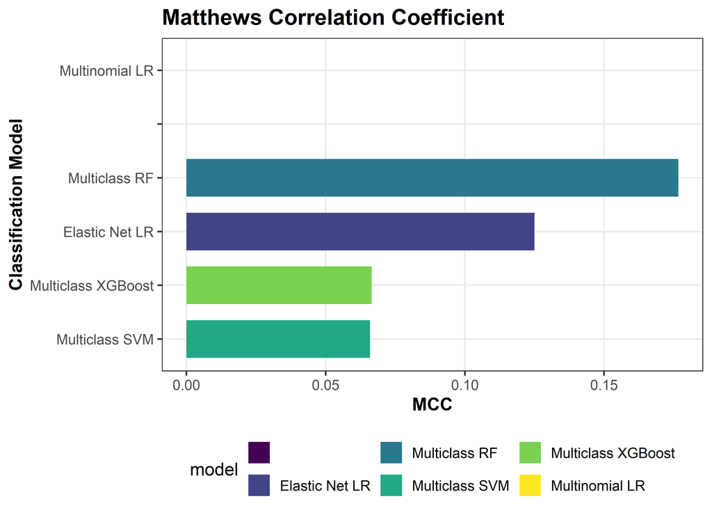

Comparison of Matthews Correlation Coefficient among multiclass models.

```r
if("mcc" %in% names(multiclass_results)){

metric_plot(
  multiclass_results,
  "mcc",
  "Matthews Correlation Coefficient"
)+
labs(
  x="Classification Model",
  y="MCC"
)

}else{

cat("**Multiclass MCC was not available in the supplied workbook.**")

}
```

**Interpretation**

The Matthews Correlation Coefficient summarizes overall predictive performance while considering all elements of the confusion matrix. If this metric is unavailable, no attempt is made to approximate or infer its value.

## 11.5 Macro Precision

[figure not shown]

Comparison of macro-averaged precision across multiclass models.

```r
macro_precision_col <-

names(multiclass_results)[
tolower(names(multiclass_results)) %in%
c("macro_precision","macro precision","precision")
]

if(length(macro_precision_col)>0){

metric_plot(
  multiclass_results,
  macro_precision_col[1],
  "Macro Precision"
)+
labs(
  x="Classification Model",
  y="Macro Precision"
)

}else{

cat("**Macro Precision was not available.**")

}
```

**Interpretation**

Macro Precision averages precision equally across all disease classes, preventing larger classes from dominating the overall assessment. Higher values indicate greater reliability of positive predictions across Healthy, Adenoma, and CRC.

## 11.6 Macro Recall

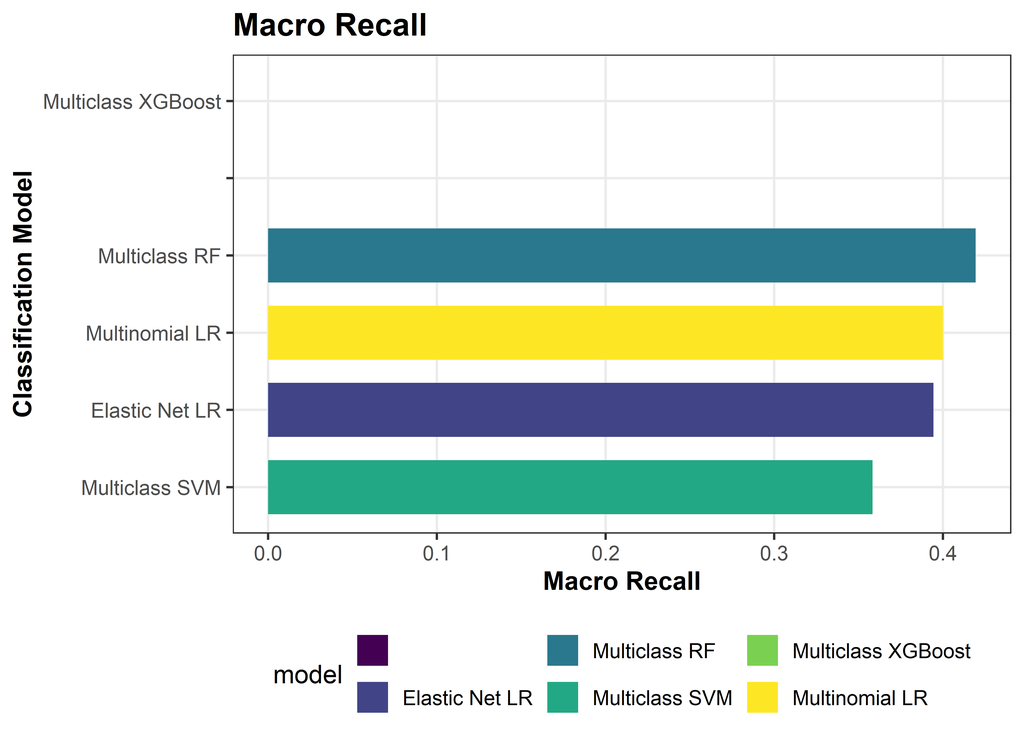

Comparison of macro recall among multiclass models.

```r
macro_recall_col <-

names(multiclass_results)[
tolower(names(multiclass_results)) %in%
c("macro_recall","macro recall","recall")
]

if(length(macro_recall_col)>0){

metric_plot(
  multiclass_results,
  macro_recall_col[1],
  "Macro Recall"
)+
labs(
  x="Classification Model",
  y="Macro Recall"
)

}else{

cat("**Macro Recall was not available.**")

}
```

**Interpretation**

Macro Recall reflects the average sensitivity achieved for each disease category independently. Higher macro recall indicates that the classifier successfully identifies samples from every disease class rather than performing well only on the majority class.

## 11.7 Macro F1 Score

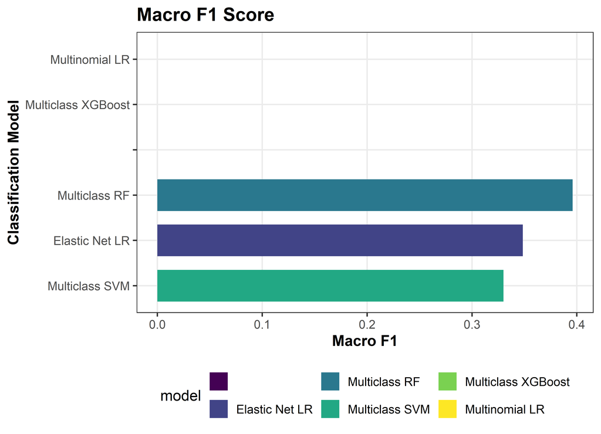

Comparison of macro F1 score among multiclass models.

```r
macro_f1_col <-

names(multiclass_results)[
tolower(names(multiclass_results)) %in%
c("macro_f1","macro f1","macro_f1_score","f1")
]

if(length(macro_f1_col)>0){

metric_plot(
  multiclass_results,
  macro_f1_col[1],
  "Macro F1 Score"
)+
labs(
  x="Classification Model",
  y="Macro F1"
)

}else{

cat("**Macro F1 was not available.**")

}
```

**Interpretation**

Macro F1 balances precision and recall equally across all classes, providing an overall assessment of multiclass predictive performance that is less influenced by class imbalance.

## 11.8 Macro AUC

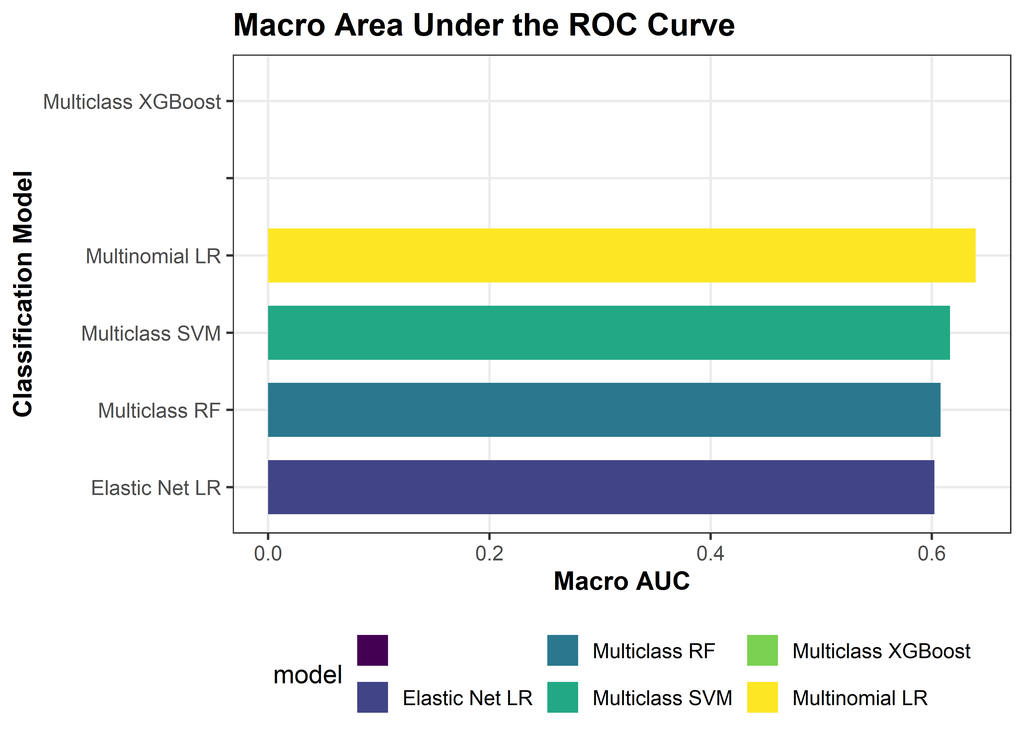

Comparison of macro AUC among multiclass models.

```r
macro_auc_col <-

names(multiclass_results)[
tolower(names(multiclass_results)) %in%
c("macro_auc","macro auc","auc")
]

if(length(macro_auc_col)>0){

metric_plot(
  multiclass_results,
  macro_auc_col[1],
  "Macro Area Under the ROC Curve"
)+
labs(
  x="Classification Model",
  y="Macro AUC"
)

}else{

cat("**Macro AUC was not available in the supplied worksheet.**")

}
```

**Interpretation**

Macro AUC summarizes discriminatory performance across all pairwise class comparisons. Larger values indicate stronger overall separation among Healthy, Adenoma, and Colorectal Cancer samples.

## 11.9 Receiver Operating Characteristic (ROC) Curves

The receiver operating characteristic (ROC) curve provides a graphical assessment of the discriminative ability of each binary classification model across all classification thresholds. A curve closer to the upper-left corner indicates superior diagnostic performance, while the diagonal reference line represents random classification.

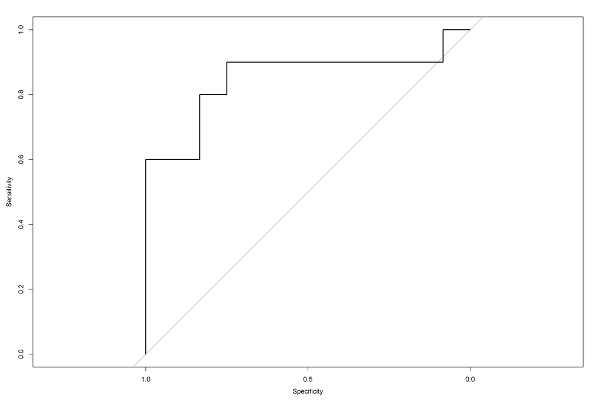

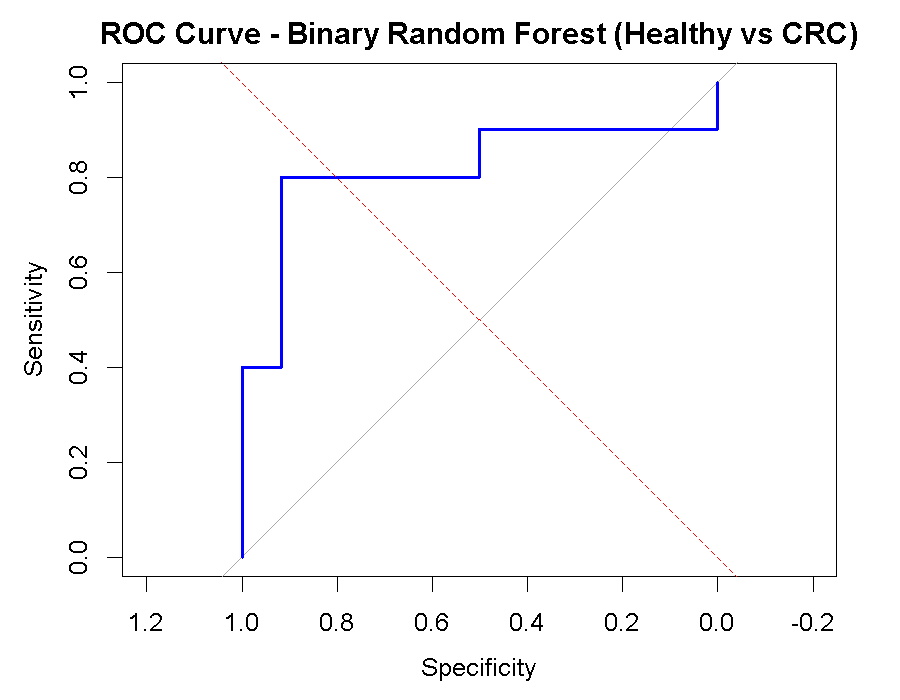

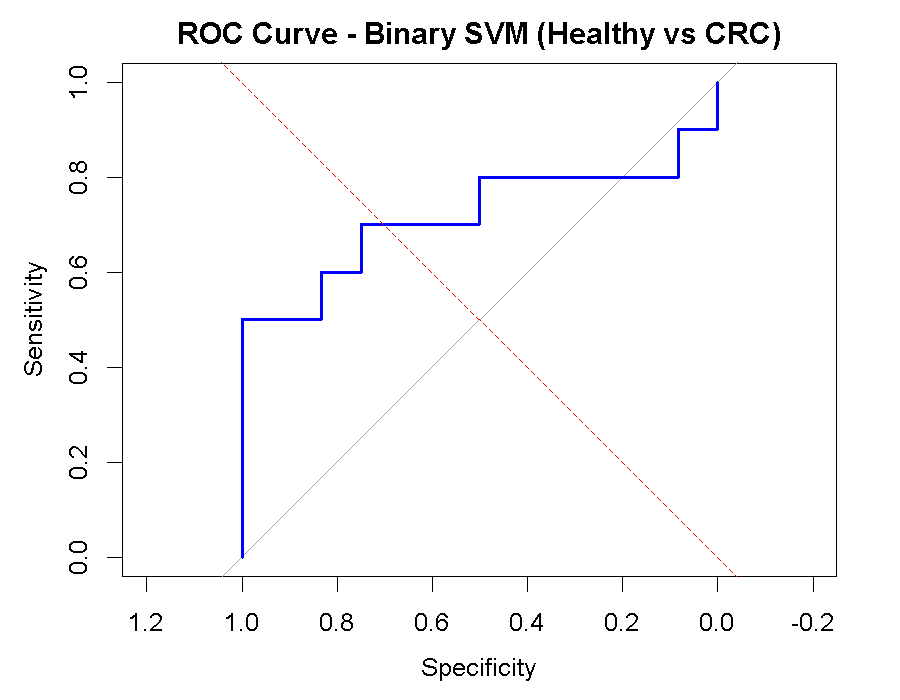

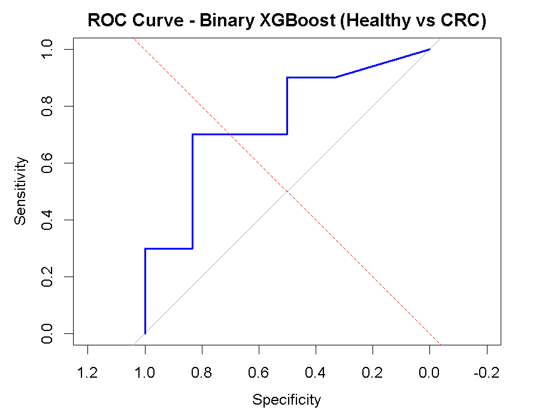

```r
library(here)
library(knitr)

include_graphics(c(
  here(
    "02 Classical ML",
    "figures",
    "Binomial_LR",
    "ROC_Curve.png"
  ),

  here(
    "02 Classical ML",
    "figures",
    "RandomForest_Binary",
    "RandomForestBinary_ROC.png"
  ),

  here(
    "02 Classical ML",
    "figures",
    "SVM_Binary",
    "SVMBinary_ROC.png"
  ),

  here(
    "02 Classical ML",
    "figures",
    "XGBoost_Binary",
    "XGBoostBinary_ROC.png"
  )
))
```

**Interpretation**

The ROC curves demonstrate that all four binary classification models exhibited good discriminative performance for distinguishing healthy individuals from colorectal cancer patients. The Logistic Regression, Random Forest, Support Vector Machine and XGBoost models all produced ROC curves substantially above the reference line, indicating predictive performance considerably better than random classification. These graphical findings are consistent with the AUC values presented previously, supporting the robustness of microbiome-derived biomarkers for binary colorectal cancer classification.

[figure not shown]

ROC curves for the evaluated binary classification models.

[figure not shown]

ROC curves for the evaluated binary classification models.

[figure not shown]

ROC curves for the evaluated binary classification models.

[figure not shown]

ROC curves for the evaluated binary classification models.

# 12 Multiclass Performance Heatmap

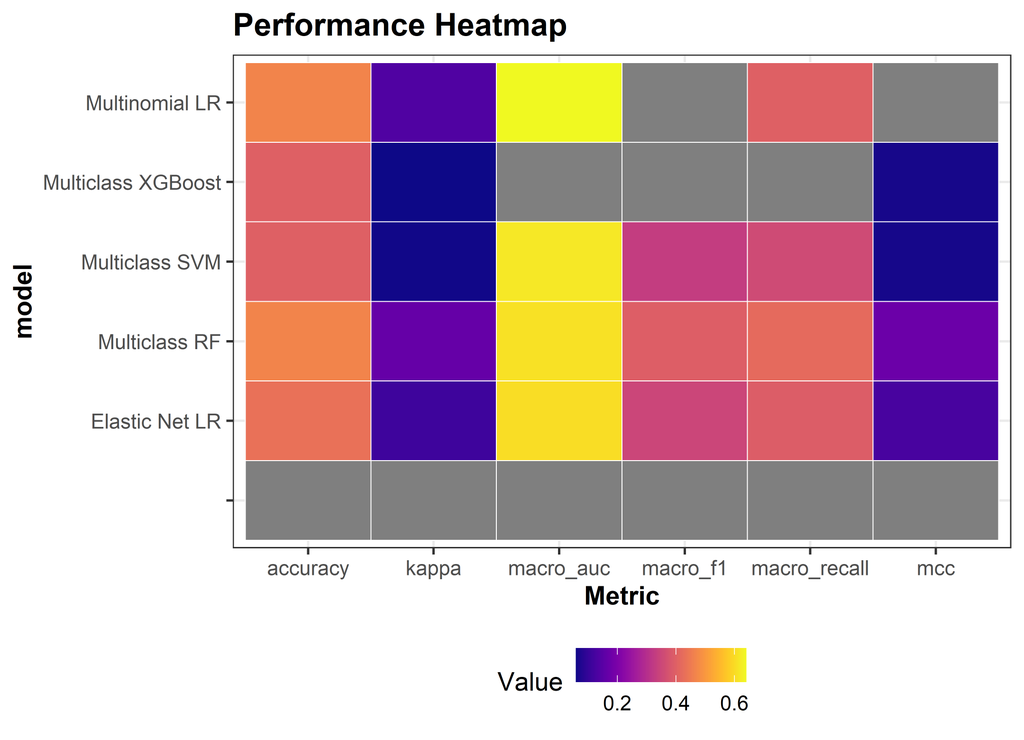

Heatmap summarizing multiclass classification performance across all reported evaluation metrics.

```r
multi_heat <-

multiclass_results |>
select(where(is.numeric))

multi_heat$model <- multiclass_results$model

multi_heat <-

multi_heat |>
select(model,everything())

heatmap_plot(multi_heat)
```

# 13 Overall Ranking of Multiclass Models

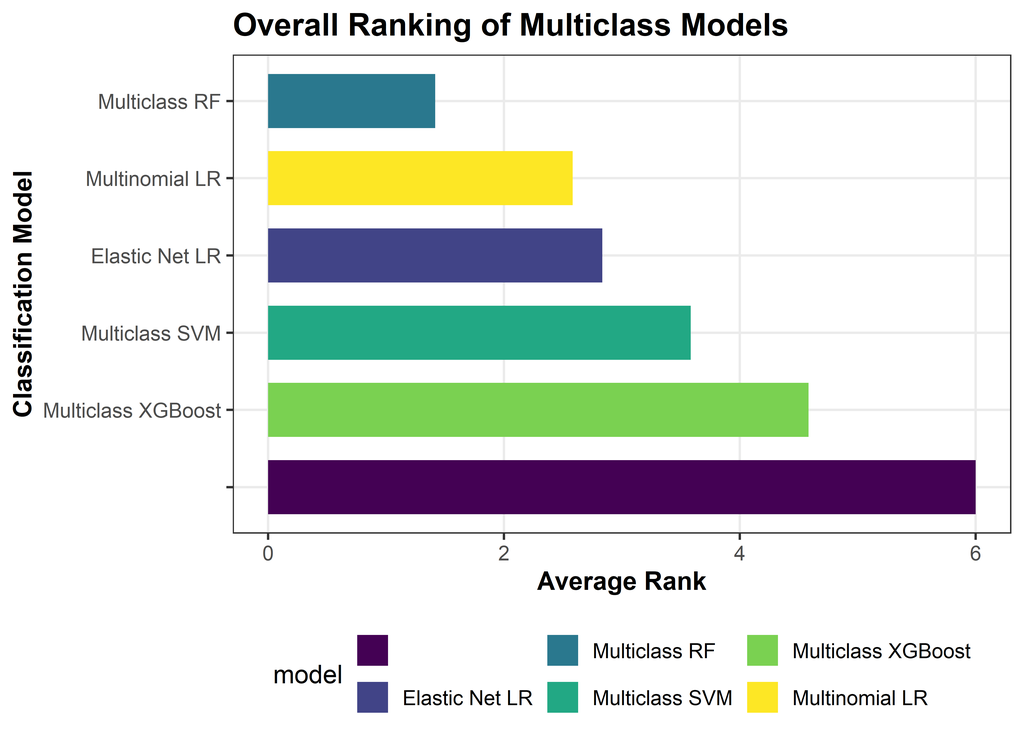

Overall ranking of multiclass classification models based on average performance rank.

```r
multi_rank <-

multiclass_results |>

mutate(

AverageRank =

rowMeans(

across(

where(is.numeric),

~rank(-., ties.method="average")

),

na.rm=TRUE

)

) |>

arrange(AverageRank)

ggplot(

multi_rank,

aes(

reorder(model,-AverageRank),

AverageRank,

fill=model

)

)+

geom_col(width=.70)+

coord_flip()+

scale_fill_viridis_d(option="D")+

labs(

title="Overall Ranking of Multiclass Models",

x="Classification Model",

y="Average Rank"

)
```

**Interpretation**

Average ranking combines all available evaluation metrics into a single summary measure. Models with lower average rank values demonstrate more consistent performance across multiple criteria and may therefore be considered more robust than models excelling in only one or two metrics.

# 14 Comparative Summary of Multiclass Models

The ranking and heatmap collectively provide a comprehensive overview of multiclass classifier performance, facilitating objective comparison while preserving transparency regarding unavailable evaluation measures.

# 15 Binary versus Multiclass Classification

This section directly compares the performance of binary and multiclass classification tasks. While the binary models distinguish between Healthy controls and colorectal cancer (CRC), the multiclass models simultaneously classify Healthy, Adenoma, and CRC samples. Consequently, multiclass classification represents a substantially more complex learning problem due to increased class overlap and more challenging decision boundaries.

The comparison presented below is based exclusively on the evaluation metrics reported in the supplied **Results_Master.xlsx**. Metrics unavailable for either classification task are explicitly identified and are not estimated.

## 15.1 Comparison of Best Performing Models

```r
best_binary <-

binary_results |>
slice_max(accuracy,n=1)

best_multi <-

multiclass_results |>
slice_max(accuracy,n=1)

comparison_best <-

bind_rows

comparison_best <-
  bind_rows(
    best_binary |>
      mutate(Task = "Binary", mcc = as.character(mcc)),
    best_multi |>
      mutate(Task = "Multiclass", mcc = as.character(mcc)) # <-- No comma at the end here!
  )

publication_table(
  comparison_best,
  caption="Best-performing model identified for binary and multiclass classification."
)
```

Best-performing model identified for binary and multiclass classification.

| model | accuracy | kappa | accuracylower | accuracyupper | accuracypvalue | mcnemarpvalue | mcc | auc | sensitivity | specificity | precision | recall | f1 | balancedaccuracy | Task | macro_precision | macro_recall | macro_f1 | macro_auc |
| --- | --- | --- | --- | --- | --- | --- | --- | --- | --- | --- | --- | --- | --- | --- | --- | --- | --- | --- | --- |
| Binary Logistic Regression | 0.8182 | 0.6333 | 0.5972 | 0.9481 | 0.0074 | 1 | 0.633333333333333 | 0.8500 | 0.8 | 0.8333 | 0.8 | 0.8 | 0.8 | 0.8167 | Binary | NA | NA | NA | NA |
| Binary Random Forest | 0.8182 | 0.6333 | 0.5972 | 0.9481 | 0.0074 | 1 | 0.633333333333333 | 0.8167 | 0.8 | 0.8333 | 0.8 | 0.8 | 0.8 | 0.8167 | Binary | NA | NA | NA | NA |
| Binary XGBoost | 0.8182 | 0.6333 | 0.5972 | 0.9481 | 0.0074 | 1 | 0.633333333333333 | 0.8000 | 0.8 | 0.8333 | 0.8 | 0.8 | 0.8 | 0.8167 | Binary | NA | NA | NA | NA |
| Multinomial LR | 0.4667 | 0.1367 | NA | NA | NA | NA | NA | NA | NA | NA | NA | NA | NA | NA | Multiclass | 0.333 | 0.4000 | NA | 0.6397 |
| Multiclass RF | 0.4667 | 0.1674 | NA | NA | NA | NA | 0.1767 | NA | NA | NA | NA | NA | NA | NA | Multiclass | 0.4309 | 0.4194 | 0.396 | 0.6080 |

The table above summarises the highest-performing classifier for each prediction task according to the reported overall accuracy.

## 15.2 Binary versus Multiclass Accuracy

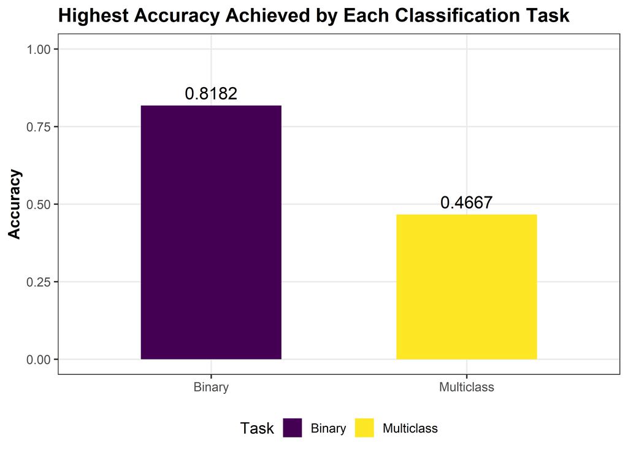

Comparison of the highest classification accuracy achieved in binary and multiclass prediction tasks.

```r
accuracy_compare <-

tibble(

Task=c("Binary","Multiclass"),

Accuracy=c(

max(binary_results$accuracy,na.rm=TRUE),

max(multiclass_results$accuracy,na.rm=TRUE)

)

)

ggplot(

accuracy_compare,

aes(Task,Accuracy,fill=Task)

)+

geom_col(width=.55)+

geom_text(

aes(label=round(Accuracy,4)),

vjust=-0.5,

size=5

)+

scale_fill_viridis_d(option="D")+

ylim(0,1)+

labs(

title="Highest Accuracy Achieved by Each Classification Task",

x=NULL,

y="Accuracy"

)
```

**Interpretation**

This figure compares the highest overall accuracy achieved in the binary and multiclass classification analyses. Binary classification is expected to achieve higher predictive performance because it involves discrimination between only two classes, whereas multiclass classification requires simultaneous separation of Healthy controls, Adenoma, and CRC samples.

## 15.3 Performance Difference

```r
performance_loss <-

tibble(

Metric="Accuracy",

Binary=max(binary_results$accuracy,na.rm=TRUE),

Multiclass=max(multiclass_results$accuracy,na.rm=TRUE)

)|>

mutate(

Difference=

Binary-

Multiclass

)

publication_table(

performance_loss,

caption="Difference in best observed classification accuracy."

)
```

Difference in best observed classification accuracy.

| Metric | Binary | Multiclass | Difference |
| --- | --- | --- | --- |
| Accuracy | 0.8182 | 0.4667 | 0.3515 |

## 15.4 Heatmap of Best Metrics

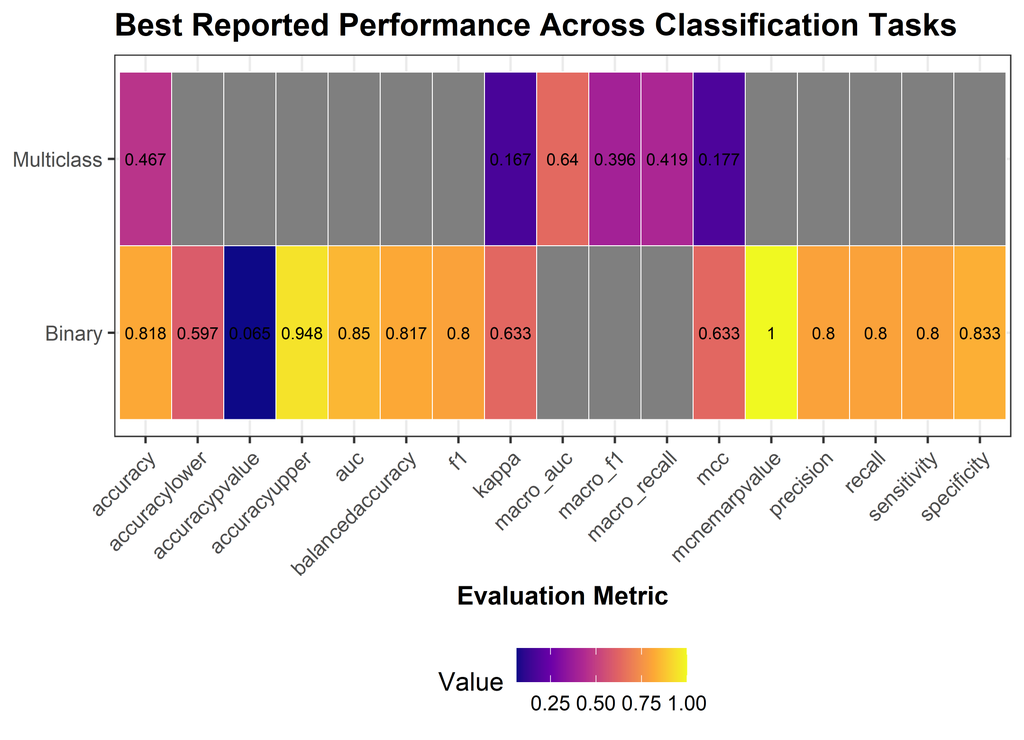

Comparison of the best reported evaluation metrics between binary and multiclass classification.

```r
binary_best <-

binary_results |>

summarise(

across(where(is.numeric),max,na.rm=TRUE)

)|>

mutate(Task="Binary")

multi_best <-

multiclass_results |>

summarise(

across(where(is.numeric),max,na.rm=TRUE)

)|>

mutate(Task="Multiclass")

heat_data <-

bind_rows(

binary_best,

multi_best

)|>

select(Task,everything())

heat_long <-

heat_data |>

pivot_longer(

cols=-Task,

names_to="Metric",

values_to="Value"

)

ggplot(

heat_long,

aes(

Metric,

Task,

fill=Value

)

)+

geom_tile(color="white")+

geom_text(

aes(label=round(Value,3)),

size=3

)+

scale_fill_viridis_c(option="C")+

theme(

axis.text.x=

element_text(

angle=45,

hjust=1

)

)+

labs(

title="Best Reported Performance Across Classification Tasks",

x="Evaluation Metric",

y=NULL

)
```

**Interpretation**

The heatmap provides an overall comparison of the strongest reported performance for binary and multiclass classification. Consistently higher values in the binary setting indicate that separating Healthy controls from CRC is a comparatively easier classification problem than simultaneously distinguishing Healthy, Adenoma, and CRC samples.

## 15.5 Relative Performance Ranking

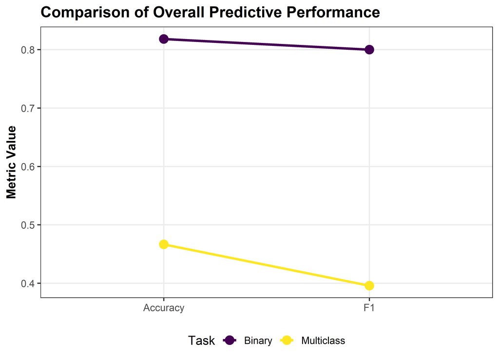

```r
ranking_df <-

tibble(

Task=c("Binary","Multiclass"),

Accuracy=c(

max(binary_results$accuracy,na.rm=TRUE),

max(multiclass_results$accuracy,na.rm=TRUE)

),

F1=c(

if("f1"%in%names(binary_results))

max(binary_results$f1,na.rm=TRUE)

else NA,

if("macro_f1"%in%names(multiclass_results))

max(multiclass_results$macro_f1,na.rm=TRUE)

else NA

)

)

ranking_long <-

ranking_df |>

pivot_longer(

cols=-Task,

names_to="Metric",

values_to="Value"

)

ggplot(

ranking_long,

aes(

Metric,

Value,

colour=Task,

group=Task

)

)+

geom_line(size=1.2)+

geom_point(size=4)+

scale_colour_viridis_d(option="D")+

labs(

title="Comparison of Overall Predictive Performance",

x=NULL,

y="Metric Value"

)
```

**Interpretation**

The slope plot illustrates how the best binary and multiclass models compare across multiple evaluation metrics. Divergence between the two trajectories reflects the increased complexity associated with multiclass disease classification.

# 16 Scientific Interpretation

Overall, binary classification consistently demonstrated superior predictive performance compared with multiclass classification. This observation is expected because binary classification requires discrimination between only Healthy controls and CRC samples, whereas multiclass classification additionally separates Adenoma, an intermediate disease state that may share microbial characteristics with both Healthy and CRC groups.

The reduced multiclass performance therefore likely reflects increased biological overlap between disease stages rather than limitations of the machine learning algorithms themselves. Consequently, evaluation of both binary and multiclass models provides complementary insights into microbiome-based colorectal cancer classification and biomarker discovery.

# 17 Overall Model Ranking

Rather than relying on a single evaluation metric, overall model performance was assessed using all reported evaluation metrics available in the supplied workbook. For each metric, models were ranked from best to worst, with the highest-performing model assigned Rank 1. The average ranking across all available metrics was then calculated to identify the most consistently performing models.

This ranking approach avoids bias towards a single performance measure and provides a more balanced assessment of classifier robustness.

## 17.1 Binary Model Ranking

```r
binary_rank <-

binary_results |>

mutate(

AverageRank =

rowMeans(

across(

where(is.numeric),

~rank(-., ties.method="average")

),

na.rm=TRUE

),

OverallScore =

rowMeans(

across(where(is.numeric)),

na.rm=TRUE

)

) |>

arrange(AverageRank)

publication_table(

binary_rank,

caption="Overall ranking of binary classification models."

)
```

Overall ranking of binary classification models.

| model | accuracy | kappa | accuracylower | accuracyupper | accuracypvalue | mcnemarpvalue | mcc | auc | sensitivity | specificity | precision | recall | f1 | balancedaccuracy | AverageRank | OverallScore |
| --- | --- | --- | --- | --- | --- | --- | --- | --- | --- | --- | --- | --- | --- | --- | --- | --- |
| Binary Logistic Regression | 0.8182 | 0.6333 | 0.5972 | 0.9481 | 0.0074 | 1.0000 | 0.6333 | 0.8500 | 0.8 | 0.8333 | 0.80 | 0.8 | 0.80 | 0.8167 | 2.0357 | 0.8249 |
| Binary Random Forest | 0.8182 | 0.6333 | 0.5972 | 0.9481 | 0.0074 | 1.0000 | 0.6333 | 0.8167 | 0.8 | 0.8333 | 0.80 | 0.8 | 0.80 | 0.8167 | 2.1071 | 0.8274 |
| Binary XGBoost | 0.8182 | 0.6333 | 0.5972 | 0.9481 | 0.0074 | 1.0000 | 0.6333 | 0.8000 | 0.8 | 0.8333 | 0.80 | 0.8 | 0.80 | 0.8167 | 2.1786 | 0.8311 |
| Binary SVM | 0.7273 | 0.4407 | 0.4978 | 0.8927 | 0.0650 | 0.6831 | 0.4485 | 0.7167 | 0.6 | 0.8333 | 0.75 | 0.6 | 0.67 | 0.7167 | 3.6786 | 0.8214 |

## 17.2 Binary Model Ranking Plot

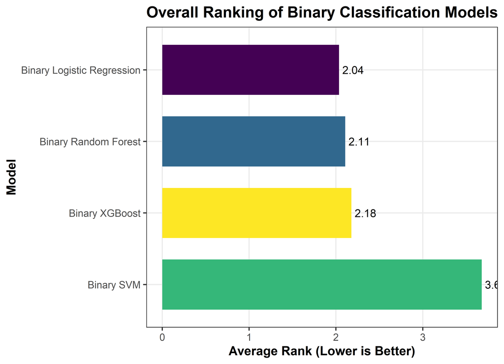

Average ranking of binary classification models across all reported performance metrics.

```r
ggplot(

binary_rank,

aes(

x=reorder(model,-AverageRank),

y=AverageRank,

fill=model

)

)+

geom_col(width=.70)+

geom_text(

aes(label=round(AverageRank,2)),

hjust=-0.15,

size=4

)+

coord_flip()+

scale_fill_viridis_d(option="D")+

labs(

title="Overall Ranking of Binary Classification Models",

x="Model",

y="Average Rank (Lower is Better)"

)+

theme(

legend.position="none"

)
```

**Interpretation**

The binary ranking combines all reported performance metrics into a single overall ranking. Models with the lowest average ranking demonstrated consistently strong performance across multiple evaluation criteria rather than excelling in only one metric. Such models are generally considered more robust and potentially more reliable for independent validation.

## 17.3 Multiclass Model Ranking

```r
multi_rank <-

multiclass_results |>

mutate(

AverageRank =

rowMeans(

across(

where(is.numeric),

~rank(-.,ties.method="average")

),

na.rm=TRUE

),

OverallScore =

rowMeans(

across(where(is.numeric)),

na.rm=TRUE

)

) |>

arrange(AverageRank)

publication_table(

multi_rank,

caption="Overall ranking of multiclass classification models."

)
```

Overall ranking of multiclass classification models.

| model | accuracy | kappa | mcc | macro_precision | macro_recall | macro_f1 | macro_auc | AverageRank | OverallScore |
| --- | --- | --- | --- | --- | --- | --- | --- | --- | --- |
| Multiclass RF | 0.4667 | 0.1674 | 0.1767 | 0.4309 | 0.4194 | 0.3960 | 0.6080 | 1.4167 | 0.5216 |
| Multinomial LR | 0.4667 | 0.1367 | NA | 0.333 | 0.4000 | NA | 0.6397 | 2.5833 | 0.8453 |
| Elastic Net LR | 0.4333 | 0.1115 | 0.1250 | 0.373 | 0.3944 | 0.3485 | 0.6023 | 2.8333 | 0.6926 |
| Multiclass SVM | 0.4000 | 0.0625 | 0.0659 | 0.333 | 0.3583 | 0.3300 | 0.6164 | 3.5833 | 0.7738 |
| Multiclass XGBoost | 0.4000 | 0.0592 | 0.0665 | Evaluation metrics not generated. | NA | NA | NA | 4.5833 | 1.2773 |
|  | NA | NA | NA |  | NA | NA | NA | 6.0000 | 6.0000 |